Data and Code Management / Autumn 2026

# Code literacy II

## Trace, modify and verify small programs

### Samuel Orso · HEC Lausanne · Data and Code Management

### Thursday, 15 October 2026

# Which statement executes next?

## Last week

Predict → run → compare a data operation.

## This week

Follow the path; change one thing; check the result.

Understand the intended behavior before accepting a change.

Use the student guide and supplied files. Python live; click “R alternative” to switch code. Both versions are also in the guide.

# A condition chooses a path

[figure not shown]

Test in order → execute the first matching branch.

A condition answers true or false. Indentation (Python) or braces (R) marks the body.

# Follow the value as the code runs

Remainder after division: Python `7 % 2 == 1`; `8 % 2 == 0`.  
R writes the same operator as `%%`. Remainder zero means divisible.

Python · live R alternative

```
x = -4
if x < 0:
    x = -x
if x % 2 == 0:
    print(f"{x} is even")
```

```
x <- -4
if (x < 0) {
  x <- -x
}
if (x %% 2 == 0) {
  cat(x, "is even\n")
}
```

Start at −4. What is x when the second condition is tested?

Two separate if statements: the second test still runs.

# Only one branch in this chain

<form class="lang-tabs" role="group" aria-label="Choose example language">
<input class="choose-python" type="radio" name="language-2" id="python-2" checked><label for="python-2">Python · live</label>
<input class="choose-r" type="radio" name="language-2" id="r-2"><label for="r-2">R alternative</label>
<pre><code data-lang="python">x = 0
if x == 0:
    print(&quot;zero&quot;)
elif x % 2 == 0:
    print(&quot;even&quot;)
else:
    print(&quot;odd&quot;)</code></pre>
<pre><code data-lang="r">x &lt;- 0
if (x == 0) {
  cat(&quot;zero\n&quot;)
} else if (x %% 2 == 0) {
  cat(&quot;even\n&quot;)
} else {
  cat(&quot;odd\n&quot;)
}</code></pre>
</form><p class="question">Predict the output for x = 0, then x = 3.</p><p class="note">else runs when the earlier conditions are false. Change only the supplied input.</p>

# One condition is not a mask

## A question per player

Week 4: titles > 0 gave  
True, True, True, False, False.

## One answer for a branch

Does this one denominator equal zero?  
The answer controls the next statement.

Use one non-missing Boolean / logical value for a branch.

`any(mask)`: at least one? `all(mask)`: every one?  
These are new questions, not automatic repairs for a vector condition.

R vector if / || and a multi-value NumPy condition error; they do not select the first element.

# A finite loop repeats the body

<form class="lang-tabs" role="group" aria-label="Choose example language">
<input class="choose-python" type="radio" name="language-3" id="python-3" checked><label for="python-3">Python · live</label>
<input class="choose-r" type="radio" name="language-3" id="r-3"><label for="r-3">R alternative</label>
<pre><code data-lang="python">for number in range(1,7):
    print(number)</code></pre>
<pre><code data-lang="r">for (number in 1:6) {
  print(number)
}</code></pre>
</form><table><thead><tr><th>Current number</th><th>Statement</th><th>Output</th></tr></thead><tbody><tr><td>1</td><td>print(number)</td><td>1</td></tr><tr><td>2</td><td>print(number)</td><td>2</td></tr><tr><td>… → 6</td><td>same body</td><td>… → 6</td></tr></tbody></table><p class="question">Which value comes next? Where does the repetition stop?</p>

# Practice · Trace the supplied FizzBuzz

<form class="lang-tabs" role="group" aria-label="Choose example language">
<input class="choose-python" type="radio" name="language-4" id="python-4" checked><label for="python-4">Python · live</label>
<input class="choose-r" type="radio" name="language-4" id="r-4"><label for="r-4">R alternative</label>
<pre><code data-lang="python">for i in range(1, 21):
    if i % 15 == 0: print(&quot;FizzBuzz&quot;)
    elif i % 3 == 0: print(&quot;Fizz&quot;)
    elif i % 5 == 0: print(&quot;Buzz&quot;)
    else: print(i)</code></pre>
<pre><code data-lang="r">for (i in 1:20) {
  if (i %% 15 == 0) cat(&quot;FizzBuzz\n&quot;)
  else if (i %% 3 == 0) cat(&quot;Fizz\n&quot;)
  else if (i %% 5 == 0) cat(&quot;Buzz\n&quot;)
  else cat(i, &quot;\n&quot;)
}</code></pre>
</form><p class="question">Predict 3, 5 and 15. Why must the combined case come first?</p><p class="note">5 minutes · Then change the upper bound to include 21. Run and check the last output.Code is supplied in <code>control-flow.py</code> / <code>control-flow.R</code>; no blank-page implementation.</p>

# Check the path, not just the printed label

| Input | First matching test | Output |
| --- | --- | --- |
| 3 | multiple of 3 | Fizz |
| 5 | multiple of 5 | Buzz |
| 15 | multiple of 15 | FizzBuzz |
| 21 · after bound edit | multiple of 3 | Fizz |

A matching branch ends this chain; later tests are skipped.

With the “multiple of 3” branch first, 15 would print Fizz. Correct syntax can still express the wrong rule.

# A function returns a result to its caller

<form class="lang-tabs" role="group" aria-label="Choose example language">
<input class="choose-python" type="radio" name="language-5" id="python-5" checked><label for="python-5">Python · live</label>
<input class="choose-r" type="radio" name="language-5" id="r-5"><label for="r-5">R alternative</label>
<pre><code data-lang="python">def my&#95;div(numerator, denominator):
    div = numerator / denominator
    return div</code></pre>
<pre><code data-lang="r">my&#95;div &lt;- function(numerator, denominator) {
  div &lt;- numerator / denominator
  return(div)
}</code></pre>
</form>inputs → body → returned result<p class="question">Predict <code>my_div(4, 2)</code>. Defining the function does not yet run its body.</p>

# Arguments enter; local names stay inside

<form class="lang-tabs" role="group" aria-label="Choose example language">
<input class="choose-python" type="radio" name="language-6" id="python-6" checked><label for="python-6">Python · live</label>
<input class="choose-r" type="radio" name="language-6" id="r-6"><label for="r-6">R alternative</label>
<pre><code data-lang="python">my&#95;div(1, 2)
my&#95;div(numerator=1, denominator=2)
div = 99
result = my&#95;div(4, 2)
print(result)
print(div)</code></pre>
<pre><code data-lang="r">my&#95;div(1, 2)
my&#95;div(numerator = 1, denominator = 2)
div &lt;- 99
result &lt;- my&#95;div(4, 2)
result
div</code></pre>
</form><p class="question">Both calls at the top return 0.5. Is the outer div still 99?</p>

# Computing a value is not always returning it

<form class="lang-tabs" role="group" aria-label="Choose example language">
<input class="choose-python" type="radio" name="language-7" id="python-7" checked><label for="python-7">Python · live</label>
<input class="choose-r" type="radio" name="language-7" id="r-7"><label for="r-7">R alternative</label>
<pre><code data-lang="python">def f(x):
    x + 1
print(f(2))</code></pre>
<pre><code data-lang="r">f &lt;- function(x) { x + 1 }
f(2)</code></pre>
</form><table><thead><tr><th>Python</th><th>R</th></tr></thead><tbody><tr><td>No return → None</td><td>Last expression → 3</td></tr></tbody></table><p class="note">The intended behavior is “input plus one”. Printing a call shows what came back.</p>

# Practice · Make one controlled change

6 minutes · one language · functions.py / functions.R

2 min

Predict, then repair the missing Python return. In R, explain the implicit return and make it explicit.

2 min

Check **2 → 3** and **0 → 1**.

2 min

Change the increment from one to two. Check **2 → 4**; explain the single change.

Preserve the function input. Change only the requested behavior.

Instructions and worked checks · reload your edited definition before checking.

# State the assumptions before adding checks

Our division exercise takes one ordinary finite real number per input.

## Valid inputs

Negative values are valid.  
A zero numerator is valid.

## Invalid text

Text should raise a useful error.  
Do not silently turn it into missing.

Outside this exercise: arrays, vector recycling/broadcasting, complex/Boolean inputs, and pre-existing missing or non-finite values.

Python: math.nan (numeric NaN), not None.  
R: NA_real_ (missing numeric); NaN means an undefined numeric result.

# An error stops; a warning can continue

<form class="lang-tabs" role="group" aria-label="Choose example language">
<input class="choose-python" type="radio" name="language-8" id="python-8" checked><label for="python-8">Python · live</label>
<input class="choose-r" type="radio" name="language-8" id="r-8"><label for="r-8">R alternative</label>
<pre><code data-lang="python">import warnings
warnings.warn(&quot;Check the inputs&quot;)
print(&quot;Execution continues&quot;)</code></pre>
<pre><code data-lang="r">warning(&quot;Check the inputs&quot;)
print(&quot;Execution continues&quot;)</code></pre>
</form><table><thead><tr><th>Signal</th><th>What to inspect</th></tr></thead><tbody><tr><td>Error</td><td>Current operation stops: read message, operation and arguments.</td></tr><tr><td>Warning</td><td>Execution ordinarily continues: check the result before using it.</td></tr></tbody></table><p class="note">A warning is not proof that the returned value is safe.</p>

# What is average revenue when there are no orders?

`average_revenue = revenue / number_of_orders`

| Store | Revenue | Orders | Average |
| --- | --- | --- | --- |
| A | 1000 | 50 | 20 |
| B | 0 | 0 | ? |

Zero orders: is “zero revenue per order” a meaningful average?

Our chosen policy: warn + return Python math.nan / R NA_real_.

Zero suggests an observed average; infinity does not describe one.  
Modify the same my_div to meet this new requirement.

# Debug one hypothesis at a time

## 1 · Reproduce

Same input, same observed failure.

## 2 · Locate

Which operation and actual arguments?

## 3 · Hypothesize

What explains expected ≠ observed?

## 4 · Change one thing

Inspect the proposed edit.

## 5 · Rerun

Repeat the original failing case.

## 6 · Verify

Check normal and edge cases too.

`my_div("a", 2)`: text reaches the division operation.  
Read the error type/message and the relevant line in your function.

# Practice · Reject text, preserve division

8 minutes · manual work · no AI yet

2 min

Run the supplied my_div with text. Identify the message, operation and actual inputs.

3 min

Add the supplied text guard before division. Keep the function’s name and arguments.

3 min

Check 4/2 → 2, 0/2 → 0, −4/2 → −2; text in either argument must error. Predict and observe 2/0.

Copyable guard and instructions. Do not add zero handling yet.

One deliberate edit: make the text failure useful.

# A useful guard explains the failure

<form class="lang-tabs" role="group" aria-label="Choose example language">
<input class="choose-python" type="radio" name="language-9" id="python-9" checked><label for="python-9">Python · live</label>
<input class="choose-r" type="radio" name="language-9" id="r-9"><label for="r-9">R alternative</label>
<pre><code data-lang="python">def my&#95;div(numerator, denominator):
    if isinstance(numerator, str) or isinstance(denominator, str):
        raise TypeError(&quot;numerator and denominator must be numbers, not text&quot;)
    return numerator / denominator</code></pre>
<pre><code data-lang="r">my&#95;div &lt;- function(numerator, denominator) {
  if (is.character(numerator) || is.character(denominator)) {
    stop(&quot;numerator and denominator must be numbers, not text&quot;)
  }
  return(numerator / denominator)
}</code></pre>
</form><p class="question">Read the guard as: “Is either input text?”</p><p class="note">Text now gets a useful error before division. The ordinary numeric results are unchanged.Zero-denominator behavior is still the original behavior.</p>

# Before AI · Define success and reproduce

Minutes 0–3 · first predict, then run · no AI

| Inputs | Required result | Signal |
| --- | --- | --- |
| (4, 2) | 2 | none |
| (2, 0) | math.nan / NA_real_ | useful warning |
| (0, 2) | 0 | none |
| (−4, 2) | −2 | none |
| ("a", 2) and (2, "a") | no result | useful input error |

Run your current my_div(2, 0). Locate the division and explain the mismatch.

These checks are fixed before asking AI. Preserve the text guard and ordinary division.

# Ask for the smallest change

Minutes 3–5 · contract + current code + observed behavior

Paste your prediction, current function and observed failing call.  
Keep `my_div(numerator, denominator)` and its arguments.  
Python standard-library modules are permitted; R base functions suffice.

No AI access? Propose the edit with a partner, then compare with the guide’s worked solution.

# Inspect the proposal before running it

Minutes 5–8 · compare old and proposed code

01

Where is the denominator-zero check?

02

Where does it warn and return missing?

03

Where does normal division still happen?

04

Does text in either argument error before division?

A small diff is evidence of what changed—not evidence that it works.

Reject unrelated rewrites, a hard-coded answer, returning zero, or hiding every error.

# Run your independent checks

Minutes 8–16 · reload the revised definition

Python · live R alternative

```
import math
result = my_div(2, 0)  # also observe the warning
print(math.isnan(result))   # checks only the value
my_div("a", 2)           # run errors separately
my_div(2, "a")
```

```
result <- my_div(2, 0)  # also observe the warning
is.na(result) && !is.nan(result)
my_div("a", 2)          # run errors separately
my_div(2, "a")
```

Run all cases from slide 20. A missing value alone does not prove a warning occurred.

Confirm the warning separately in a fresh session; repeat warnings may be suppressed.  
**Invent one additional input: predict, run, and explain what it tests.**

# Accept only what the evidence supports

Minutes 16–19 · decision

“I accept / reject this proposal because…”

## Behavior checked

Original mismatch addressed?  
Normal and invalid inputs still handled?

## Change understood

Which branch runs?  
What evidence supports your decision?

AI-generated code is a proposal; the analyst must understand the change  
and provide evidence that it satisfies the intended behavior.

Worked scalar solution · compare after testing. Passing these cases does not prove universal robustness.

# The tests pass. Is the code ready to use?

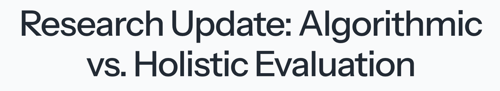

David Rein · METR

18 tasks attempted.  
15 pull requests reviewed.  
**0 mergeable as-is**—even some passing reference tests.

01

Why might passing tests still leave code unsuitable for use?

02

Our `my_div()` passes every supplied check. Accept it? What else matters?

03

Is this specific to AI-generated code?

6-minute discussion**1 min reflect · 4 min discuss · 1 min conclude**

Study context: an early-2025 agent, two mature open-source repositories.  
[Read: TL;DR, Results and Caveats](https://metr.org/blog/2025-08-12-research-update-towards-reconciling-slowdown-with-time-horizons/) · sufficient preparation.

# A change you can explain and defend

Trace

Which condition and statements executed?

Diagnose

Which input and operation explain the mismatch?

Verify

Which normal, edge and invalid cases did you check?

Keep your prediction, reviewed change and observed checks.

22 October: Responsible AI at UNIL · asynchronous.  
29 October: SQL & relational data.